# Causes and consequences of downsizing: Towards an integrative framework

Converted from PDF `Gandolfi-DownsizingIntegrativeFramework-2011-JMO.pdf` · 25 pages · anchors: page `#pN`, block `#pN-bK`

Page 1

### LITERATURE REVIEW Causes and consequences of downsizing: Towards an integrative framework

**Article** *in* Journal of Management & Organization · July 2011

#### **2 authors:**

Franco Gandolfi

Georgetown University

**63** PUBLICATIONS **763** CITATIONS

Magnus Hansson

Örebro University

**59** PUBLICATIONS **365** CITATIONS

Page 2

Copyright © eContent Management Pty Ltd. *Journal of Management & Organization* (2011) **17**: 498–521.

JOURNAL OF MANAGEMENT & ORGANIZATION Volume 17, Issue 4, July 2011 498

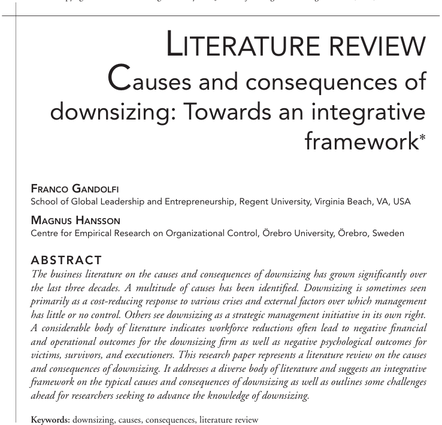

NOTE: figure/graphic rendered as an image from the PDF; its content is not machine-readable text. Caption (if any) follows as the next block.

**text found inside the figure**

LITERATURE REVIEW Causes and consequences of downsizing: Towards an integrative

framework<sup>∗</sup>

FRANCO GANDOLFI School of Global Leadership and Entrepreneurship, Regent University, Virginia Beach, VA, USA

MAGNUS HANSSON Centre for Empirical Research on Organizational Control, Örebro University, Örebro, Sweden

ABSTRACT *The business literature on the causes and consequences of downsizing has grown signifi cantly over the last three decades. A multitude of causes has been identifi ed. Downsizing is sometimes seen primarily as a cost-reducing response to various crises and external factors over which management has little or no control. Others see downsizing as a strategic management initiative in its own right. A considerable body of literature indicates workforce reductions often lead to negative fi nancial and operational outcomes for the downsizing fi rm as well as negative psychological outcomes for victims, survivors, and executioners. This research paper represents a literature review on the causes and consequences of downsizing. It addresses a diverse body of literature and suggests an integrative framework on the typical causes and consequences of downsizing as well as outlines some challenges ahead for researchers seeking to advance the knowledge of downsizing.*

**Keywords:** downsizing, causes, consequences, literature review

## INTRODUCTION T

he research on downsizing has emerged largely from the 1980s onward after years of being a neglected topic in organizational science (De Meuse & Marks, 2003; Mellahi & Wilkinson, 2004; Whetten, 1980). A multitude of studies covering a wide range of different aspects of downsizing in various countries and regions have been conducted (Gandolfi , 2006a). Studies have involved various elements and facets drawing

from several academic disciplines, including Industrial Organization, Organizational Ecology, Organizational Studies, and Organizational Psychology (Mellahi & Wilkinson, 2004).

The body of literature on downsizing is substantial, refl ecting its prevalence in the U.S., the U.K, Canada, Europe, Australia, New Zealand, and Japan in the 1980s, 1990s, and the early days of the new millennium (Cameron, 1994; Cameron, Freeman, & Mishra, 1991, 1993;

*Dedicated to Craig R Littler.

Page 3

Causes and consequences of downsizing

Volume 17, Issue 4, July 2011 JOURNAL OF MANAGEMENT & ORGANIZATION 499

severance payments (Barker & Duhaime, 1997; Barker & Mone, 1994; Downs, 1995; Robbins & Pearce, 1992), failure in reducing costs (Gandolfi & Hansson, 2010), and decreasing returns on assets and return on common stock (Cascio, 1991, 1993; Cascio et al., 1997).

Given the complex and multifaceted nature of downsizing as a phenomenon and the cumulative development of the associated literature spanning over more than three decades, we argue that there is a need for a review of the literature in order to generate a picture of what we know and what have we learned (see also: Cascio, 1993). First, the literature on downsizing has grown considerably and continues to expand at a rapid pace while less time has been spent on capturing and covering the increasing body of knowledge on this salient topic. Second, we believe that the continued accumulation of the multitude of fi ndings will support researchers and practitioners in their understanding of the causes and consequences of downsizing. By doing so, the review proposes an integrative framework on the causes and consequences of downsizing (see Figure 1).

This research paper begins by examining the history, defi nition, and scope of downsizing. Subsequently, the focus shifts to the causes of downsizing and the fi nancial, organizational, and human consequences following the conduct of downsizing. In the fi nal sections, the paper presents contemporary downsizing practices, suggests an integrative framework, and outlines the challenges ahead for researchers seeking to advance the knowledge of downsizing.

HISTORY, DEFINITION, AND SCOPE Where did the term downsizing come from? A considerable number of management terms have originated with the automobile industry and, surprisingly perhaps, *downsizing* fi nds its origin there as well. By 1970, the average American family car weighed 2 tons, stretched over 17 feet long, and often sported a massive V-8 engine. Big was beautiful, and bigger was better. The oil crisis of 1973 generated the need for smaller family cars with reasonable performance and economy. Producing

Cascio, 1993; Dolan, Belout, & Balkin, 2000; Gandolfi & Neck, 2003; Farrell & Mavondo, 2004; Littler, 2000). While downsizing has developed into a ‘popularist’ term (Littler, 1998) that has arisen out of managerial press usage (Littler, Dunford, Bramble, & Hede, 1997), it lacks precise theoretical formulation (Macky, 2004).

As is evident from the literature, there is a wide range of downsizing causes, drivers, and driving forces, yet no single cause seems to be able to explain and account for the emergence and pervasiveness of the phenomenon (Datta, Guthrie, Basuil, & Pandey, 2010). So-called ‘classical’ causes of downsizing involve cost reducing efforts (Radcliffe, Campbell, & Fogarty, 2001), ‘failures’, including failures to adopt to changing technology, niche dynamics, and insuffi cient management skills (Mellahi & Wilkinson, 2004), responses to various types of crises and external factors (Espahbodi, John, & Vasudevan, 2000), and global competition (Mirabal & DeYoung, 2005).

Downsizing generates negative performance outcomes, such as the failure to reduce costs, the lack of signifi cant increase in return on assets and return on common stock (Cascio, 1991, 1993; Cascio, Young, & Morris, 1997), decreased levels of worker commitment (Cameron et al., 1993) and commitment (Zatzick & Iverson, 2006), and the emergence of the ‘dirty dozen’ – a list of negative attributes associated with organizational decline (Cameron, 1994). A number of downsizing studies address the ‘survivor syndrome’ as a cluster of negative workforce outcomes (Brockner, Davy, & Carter, 1985; Brockner et al., 1986a, 1986b; Brockner, Greenberg, & Grover, 1988a). Downsizing research reports decreased employee efforts and adaptability, increased propensity to leave, and increased resistance to change (Brockner, 1992; Brockner, Grover, & Blonder, 1988b; Greenhalgh & Rosenblatt, 1984; Littler, Wiesner, & Dunford, 2003). Further, studies on the fi nancial consequences of downsizing raise problematic costs associated with downsizing activities (Atwood, Coke, Cooper, & Loria, 1995). These include deteriorating shareholder value (Appelbaum, Everard, & Hung, 1999a), effects of

Page 4

Franco Gandolfi and Magnus Hansson

JOURNAL OF MANAGEMENT & ORGANIZATION Volume 17, Issue 4, July 2011 500

In the early 1980s, downsizing came into prominence as a topic of both scholarly and practical concern. It became the management ‘catch-cry’ of the 1990s which subsequently became known as the ‘downsizing decade’ (Dolan et al., 2000, p. 34). As a strategic managerial tool, it has changed tens of thousands of companies and governmental bodies and the lives of millions of blue and white-collar workers around the world (Amundson, Borgen, Jordan, & Erlebach, 2004).

How can downsizing be defi ned? According to Cameron (1994, p. 192), downsizing is defi ned as:

… a set of activities, undertaken on the part of the management of an organization and designed to improve organizational effi ciency, productivity, and/or competitiveness.

these vehicles became known as ‘downsizing’ in the U.S. auto industry. Thus, the term downsizing was coined to defi ne the scaling down of car sizes by automobile manufacturers (Appelbaum, Simpson, & Shapiro, 1987). In an organizational setting, the term was fi rst applied to a process of cutting back employees when business and government in the U.S. began making major reductions to their employee bases in response to recessionary pressures in the 1980s. As a consequence, downsizing became associated with workforce reduction strategies (Halley, 1995) and a strategy to streamline, tighten, and shrink the organizational structure with respect to the number of personnel employed by the fi rm. As downsizing became more prevalent, the term was applied to a broader range of managerial efforts to improve a fi rm’s performance.

FIGURE 1: TYPICAL CAUSES AND CONSEQUENCES OF DOWNSIZING

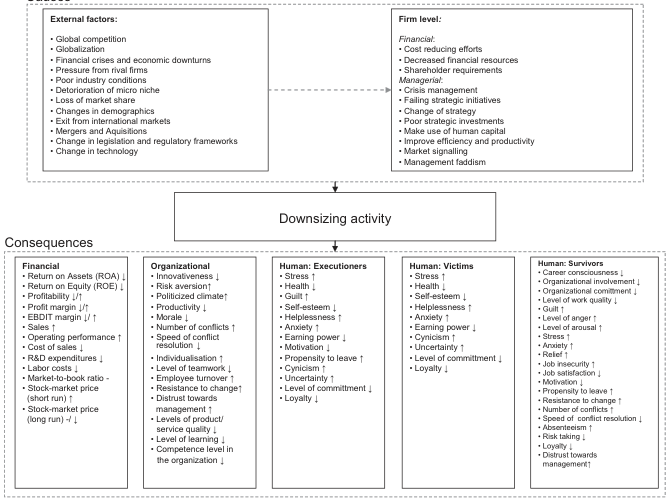

NOTE: figure/graphic rendered as an image from the PDF; its content is not machine-readable text. Caption (if any) follows as the next block.

**text found inside the figure**

**External factors:**

• Global competition • Globalization • Financial crises and economic downturns • Pressure from rival firms • Poor industry conditions • Detorioration of micro niche • Loss of market share • Changes in demographics • Exit from international markets • Mergers and Aquisitions • Change in legislation and regulatory frameworks • Change in technology

**Firm level*:***

*Financial*: • Cost reducing efforts • Decreased financial resources • Shareholder requirements *Managerial*: • Crisis management • Failing strategic initiatives • Change of strategy • Poor strategic investments • Make use of human capital • Improve efficiency and productivity • Market signalling • Management faddism

**Financial** • Return on Assets (ROA) ↓ • Return on Equity (ROE) ↓ • Profitability ↓/↑ • Profit margin ↓/↑ • EBDIT margin ↓/ ↑ • Sales ↑ • Operating performance ↑ • Cost of sales ↓ • R&D expenditures ↓ • Labor costs ↓ • Market-to-book ratio - • Stock-market price (short run) ↑ • Stock-market price (long run) -/ ↓

**Organizational** • Innovativeness ↓ • Risk aversion↑ • Politicized climate↑ • Productivity ↓ • Morale ↓ • Number of conflicts ↑ • Speed of conflict

• Individualisation ↑ • Level of teamwork ↓ • Employee turnover ↑ • Resistance to change↑ • Distrust towards management ↑ • Levels of product/ service quality ↓ • Level of learning ↓ • Competence level in the organization ↓

**Human: Executioners** • Stress ↑ • Health ↓ • Guilt ↑ • Self-esteem ↓ • Helplessness ↑ • Anxiety ↑ • Earning power ↓ • Motivation ↓ • Propensity to leave ↑ • Cynicism ↑ • Uncertainty ↑ • Level of committment ↓ • Loyalty ↓

**Human: Victims** • Stress ↑ • Health ↓ • Self-esteem ↓ • Helplessness ↑ • Anxiety ↑ • Earning power ↓ • Cynicism ↑ • Uncertainty ↑ • Level of committment ↓ • Loyalty ↓

**Human: Survivors** • Career consciousness ↓ • Organizational involvement ↓ • Organizational comittment ↓ • Level of work quality ↓ • Guilt ↑ • Level of anger ↑ • Level of arousal ↑ • Stress ↑ • Anxiety ↑ • Relief ↑ • Job insecurity ↑ • Job satisfaction ↓ • Motivation ↓ • Propensity to leave ↑ • Resistance to change ↑ • Number of conflicts ↑ • Speed of conflict resolution ↓ • Absenteeism ↑ • Risk taking ↓ • Loyalty ↓ • Distrust towards management↑

Consequences

Downsizing activity

resolution ↓

Causes

Page 5

Causes and consequences of downsizing

Volume 17, Issue 4, July 2011 JOURNAL OF MANAGEMENT & ORGANIZATION 501

contraction of labor resources. Put differently, companies resort to downsizing when they intentionally eliminate positions or jobs.

Evidently, the majority of downsizing research has been conducted in the U.S. (Chadwick, Hunter, & Walston, 2004). Still, the contraction of workforces has not been confi ned to U.S. fi rms, but has occurred throughout the world (Ryan & Macky, 1998). Empirical evidence shows that downsizing and its many related concepts has been particularly pervasive in North America (Freeman, 1994), Britain (Thornhill & Saunders, 1998), Canada (Dolan et al., 2000), Europe (Lamsa & Takala, 2000), Japan (Griggs & Hyland, 2003), Australia (Gandolfi , 2006b), New Zealand (Macky, 2004), South Africa (Littler, 1998), and Eastern Europe (Redman & Keithley, 1998). Downsizing is also prevalent in countries that are moving from a state-dominated to a market system, such as countries in Latin America, Russia, and Eastern Europe, where privatization often brings about the need to reduce fi rms’ headcounts (Appelbaum et al., 1999a,b). Downsizing has even become common in certain industrialized countries, such as Japan and Sweden, which have historically displayed very stable employment practices (Mroczkowski & Hanaoka, 1997). Cascio (2003) points out that downsizing has also affected China, which has become one of the world’s foremost manufacturing hubs. In 2003 alone, over 25 million Chinese lost their jobs from the transformation and privatization of state-owned enterprises (SOE).

In sum, empirical and anecdotal evidence suggests strongly that the intentional, purposeful adoption of downsizing as a reactive or proactive managerial strategy has occurred in all industries and sectors and impacted businesses, governments, and individuals (Macky, 2004) around the world (Mirabal & DeYoung, 2005) over the past three decades (Gandolfi , 2008).

Cameron’s defi nition embraces a holistic approach in an attempt to increase a fi rm’s overall performance. On the other end of the continuum, Cascio (1993, p 95) asserts that downsizing is essentially ‘the planned eliminations of positions or jobs’. In other words, the primary purpose of downsizing is not increased organizational performance *per se*, but the reduction of the workforce. In its narrowest sense, downsizing can be viewed as a set of activities introduced to make a fi rm more cost-effective. In its widest sense, downsizing may be seen as a complete strategic transformation intended to change an organization’s design, its work processes, corporate culture, values and attitudes, and mission (Kets de Vries & Balazs, 1997). Downsizing in its most extreme form may turn into an across-the-board cut in personnel (Kets de Vries & Balazs, 1997) or imply a re-focus on certain core businesses and a disposal of peripheral ones (Crainer & Obleng, 1995).

A precise conceptual understanding of downsizing is required to adopt a cumulative approach to academic research. Hence, four major attributes have been identifi ed. First and foremost, downsizing is an intentional set of activities that strongly implies organizational action. Second, downsizing frequently involves a reduction in the number of employees. Third, downsizing concentrates upon improving the effi ciency of a company in order to contain or decrease costs, to enhance revenues, or to increase competitiveness. Fourth, downsizing inevitably infl uences work processes and leads to some kind of work redesign (Cameron, 1998). According to Mirabal and DeYoung (2005), downsizing constitutes a reactive and defensive or proactive and anticipatory strategy implemented by management that inevitably makes a signifi cant impact upon a company’s size, costs, and work processes, as well as a fi rm’s shape and culture (Zemke, 1990). While a single defi nition of downsizing does not exist across studies, it is clear that downsizing means a contraction or shrinkage in the size of a fi rm which, frequently, implies job losses and retrenchments. For the purpose of this literature review, downsizing will be referred to as an organization’s planned

Page 6

Franco Gandolfi and Magnus Hansson

JOURNAL OF MANAGEMENT & ORGANIZATION Volume 17, Issue 4, July 2011 502

were subsequently divided into three categories; namely executioners, victims, and survivors. The identifi ed and typical categories were derived from the literature review outlined below.

Finally, this paper’s paradigmatic domicile is primarily situated within the social action theory within the functionalistic approach (Burrell & Morgan, 1979). The social action theory is one of the paradigmatic domains within the functionalistic paradigm (Burrell & Morgan, 1979). Within the social action theory realm explanations of the social world must be adequate on the level of meaning. Explanations to social affairs must account for the way in which individuals attach subjective meaning to situations and orient their action in accordance with their perceptions of those situations. The social action theory aims to incorporate idealist and positivist approaches to the study of society, bounded by the functionalistic border to subjectivistic approaches. Application of the social action theory consists of a whole range of ontological, epistemological, and methodological assumptions (Burrell & Morgan, 1979).

DOWNSIZING CAUSES Why do fi rms resort to downsizing? From a review of the downsizing literature it is evident that downsizing is a complicated and multifaceted phenomenon with a multitude of possible causes. While scholars have asserted various downsizing causes, drivers, and driving forces, no single cause can explain and account for the emergence and pervasiveness of the phenomenon. Still, there are some archetypes of causes to a downsizing decision. Taking Radcliffe et al. (2001) scheme as a starting point, ‘classical’ causes of downsizing are various types of cost reducing efforts in response to various types of crises and external factors over which management has little or no control. Frequently cited examples include global competition (Mirabal & DeYoung, 2005), pressures from rival fi rms (Luthans & Sommer, 1999), poor industry conditions (Espahbodi et al., 2000), deterioration of micro niches (Cameron, Sutton, & Whetten,

to provide a coherent and integrated portrait of the previous research.

In the downsizing literature a variety of terms have been used including but not limited to: building-down, compressing, consolidating, contracting, declining, de-hiring, de-massing, de-recruiting, dismantling, downshifting, functionalizing, leaning-up, ratcheting-down, rationalizing, reallocating, reassigning, rebalancing, rebuilding, redeploying, redesigning, reductionin-force, re-engineering, renewing, reorganizing, reshaping, resizing, restructuring, retrenching, revitalizing, rightsizing, slimming, slivering, and streamlining (Cameron, 1994; Gandolfi , 2006b; Littler et al., 1997). Given the multitude of terms, this paper focuses on and applies some of the most frequently used applied terms, such as, organizational restructuring, downsizing, delayering, reengineering, and lean production (Cameron, 1994) as the search terms we have applied for the data collection. Non-published items on the internet were not included. All references were abstracted or full copies obtained and subjected to thematic analysis.

We followed the suggested principles of Thorpe, Holt, Macpherson, and Pittaway (2005) in order to adopt a systematic review involving transparency and a broad coverage. The review was limited to published journal articles, conference proceedings, and book chapters. Comprehensiveness was achieved by cross checking references through, among others for example, the social science citation index (SSCI). To qualify for the analysis, studies must have contained and focused on causes and consequences related to the strategic initiative of downsizing.

This paper asserts the ambition to outline an integrative framework of typical causes and consequences of downsizing activities. Extracted from the literature review, we sorted explanatory factors into different categories. For the causes of downsizing we distinguished between external and fi rm-level factors and for the consequences we divided between fi nancial, organizational, and human factors. The human factors

Page 7

Causes and consequences of downsizing

Volume 17, Issue 4, July 2011 JOURNAL OF MANAGEMENT & ORGANIZATION 503

predominantly white-collar workers, especially among higher-level white-collar workers, professionals, and middle managers, as seen in the 1980s (Littler, 1998; Dolan et al., 2000). Still and as often argued by managers, fi rms downsize to make best possible use of their human, capital, and physical resources. They seek to gain effi - ciency and productivity – measured in terms of output per employee (Cascio, 1998; Chadwick et al., 2004) – and to react to temporary changes (Anthony, Perrewe, & Kacmaar, 1996). These fi rms employ outsourcing (Beylerian & Kleiner, 2003) and the increased use of contingent labor (Beylerian & Kleiner, 2003) as complementary drivers to downsizing activities.

Downsizing can also be caused by fi nancial pressures and fi nancial losses (Cameron et al., 1988; Cascio, 1991, 1993). These are among the dominant reasons to downsize and can include reductions in workforce, investments, and production equipment (Appelbaum, Lavigne- Schmidt, Peytchev, & Shapiro, 1999b; Caulkin, 1995; Marks & De Meuse, 2003). Examples of fi nancial and related pressures driving downsizing activities include decreased fi nancial resources (Cameron, 1994), demands from shareholders (Delorese, 1998), effects of mergers and acquisitions (Kets de Vries & Balazs, 1997), privatization (Allen, 1997), negative profi tability, higher operation costs, and lowered profi t margins, (Allen, 1997; Hambrick & D’Aveni, 1988), changes in customer preferences, legislation, and regulatory frameworks (Lee & Alexander, 1999; Marks & De Meuse, 2003; Zammuto & Cameron, 1985), higher administrative costs and the problems of raising capital, as well as attracting, recruiting, and retaining highly skilled workers (Aldrich & Auster, 1986). Also, poor operating and stock price performance, increased gearing, and threats from external markets for corporate control precede employee layoffs (Hillier, Marshall, McColgan, & Wereman, 2007). However, in its extreme, long-term, severe forms of fi nancial pressure, fi nancial losses, inabilities to handle payments, and different forms of bankruptcy can

1988; Hannan & Freeman, 1988, 1989), shrinking market (Harrigan, 1982), severe loss of market shares (Hedberg, Nystrom, & Starbuck, 1978; Starbuck, Greve, & Hedberg, 1978), change in demographics (Mellahi & Wilkinson, 2004), divestments (Montgomery & Thomas, 1988), exit from international markets (Jackson, Mellahi, & Sparks, 2005), failing strategic initiatives and wrong investments (Ghemawat, 1991), and other types of failures (Mellahi & Wilkinson, 2004).

Downsizing activities involve temporary and permanent job cuts (Beaumont & Harris, 2003), plant closings (Allen, Freeman, Russell, Reizenstein, & Rentz, 2001; Hansson & Wigblad, 2006a, 2006b), site closures (Gandolfi , 2006b), and layoffs (Macky, 2004). Often, cutting initiatives have been aimed at the unskilled blue-collar workers earning an hourly wage (Cameron, 1994), as well as some lower-level white-collar workers (Freeman, 1994). In some aspects and type of industries, however, there has been a shift of job-cutting targets from blue-collar workers to

Page 8

Franco Gandolfi and Magnus Hansson

JOURNAL OF MANAGEMENT & ORGANIZATION Volume 17, Issue 4, July 2011 504

for fi rms to engage in downsizing; in fact, technological improvements often resulted in hiring additional workers. Similarly, Kets de Vries and Balazs (1997) conclude that it was not the introduction of technology *per se*, but the administrative impact of the revolutionary transformation in information and communication technology, that resulted in downsizing. Still, a chief outcome of the technological advances in the 1990s was an increased redundancy of middle management (Kets de Vries & Balazs, 1997) which resulted in ‘delayering’ (Gandolfi & Hansson, 2010; Littler, 1998). From a neo-institutional perspective, a number of empirical fi ndings of drivers and driving factors that (partially) explain why organizations practice downsizing activities have been identifi ed: Downsizing rates are higher among fi rms that execute many consolidations than among those that execute fewer ones, and fi rms that make large investments in labor-saving technologies have higher downsizing rates than those that make relatively small investments in technologies (Budros, 1999, 2002, 2004). Further, downsizing rates are higher among fi rms with higher employee compensation levels than among those with lower levels, and larger fi rms have higher downsizing rates than smaller ones (Budros, 1997, 1999).

Moreover, fi rms with smaller shareholder values have higher downsizing rates than those with larger values (Budros, 2004). It is evident that fi rms under attack from raiders have higher downsizing rates than those not under attack, fi rms in deregulated industries have higher downsizing rates than those operating in regulated ones (Budros, 1999, 2004), and downsizing rates increase during economic troughs and decrease during peaks (Budros, 2004; Cascio, 1993; McKinley et al., 1995). Downsizing rates are lower among employee-centered fi rms than among those that are less employee-oriented, and downsizing rates are higher among fi rms with CEOs possessing fi nancial backgrounds than among those where the CEOs came from other educational and professional backgrounds

cause a complete workforce reduction and noncontinuity of business processes (Altman, 1971; Aziz, Emanuel, & Lawson, 1988; Chopra, 2006; Dimitras, Zanakis, & Zopounidis, 1996).

Firm behavior can be meaningfully interpreted as ‘signals’ to capital markets and stakeholders. Downsizing activities can serve as a key signal to capital markets, where executives often think that a stable or rising stock price constitutes an essential resource for the company (Littler & Gandolfi , 2008). Downsizing has been applied as a strategy in order to yield immediate increases in stock prices (Appelbaum et al., 1999a, 1999b; Downs, 1995; Fisher & White, 2000). Executives are usually aware of the positive reaction immediately following a decision to downsize, which, presumably, could be used as means of achieving shortterm positive stock price movements. Investors and fi nancial analysts could be expected to view the announced downsizing programs favorably, leading to an increase in stock prices (Appelbaum et al., 1999a, 1999b; McKinley, Sanchez, & Schick, 1995).

Harrington (1998) attributes downsizing to surpluses of both employees and facilities, the direct result of increased competition, increased effi ciency, reduced need for middle managers resulting from delayering and employee empowerment, and reductions in required maintenance resulting from improved quality and reliability of products. In a similar vein, Appelbaum et al. (1999a, 1999b) view downsizing as one of many cost-containment strategies, such as total quality management (TQM), reengineering, transaction processing, and information systems, implemented in order to streamline activities and to reduce waste and ineffi ciencies.

Downsizing can also be caused by a response to technological change and advancement (Luthans & Sommer, 1999). For example, Appelbaum et al. (1999a, 1999b) asserted that technological advancement and innovations resulted in increased productivity and a decrease in required workers. In contrast, Littler (1998) contends that a change in technology was not the primary reason

Page 9

Causes and consequences of downsizing

Volume 17, Issue 4, July 2011 JOURNAL OF MANAGEMENT & ORGANIZATION 505

effectiveness, productivity, and profi tability (Cascio, 1993; Gandolfi , 2008; Gandolfi & Neck, 2008; Guthrie & Datta, 2008; Love & Nohria, 2005; Macky, 2004; Sahdev, 2003). From the literature review, a set of common denominators can be identifi ed. This is presented in Table 1 as a chronological, non-exhaustive account of some representative studies on the fi nancial consequences of downsizing activities. First, it is obvious that researchers have applied diverse measures for their analyses. The results vary among studies as some researchers indicate positive fi nancial consequences, while others have reported negative outcomes. For instance, there are some contradictory outcomes on the return on asset ratio (ROA) and return on equity ratio (ROE). Indeed, a number of studies indicate that both employee and asset downsizers as well as employment ‘upsizers’ reduce ROA and ROE levels, while other studies do not fi nd any signifi - cant relationships (Cascio et al., 1997; Dawkins, Littler, Valenzuela, & Jensen, 1999; De Meuse, Bergmann, Vanderheiden, & Roraff, 2004; De Meuse, Vanderheiden, & Bergmann, 1994). Furthermore, asset downsizers have proved more effective than employee downsizers when it comes to the outcomes on the return on stock (ROS; Cascio et al., 1997; Worrell et al., 1991).

Second, regarding the profi tability, profi t margin, and EBDIT margin of downsized fi rms, there remains to be limited empirical data to support the notion that downsizing produces improved fi nancial outcomes (Dawkins et al., 1999; De Meuse et al., 2004; Macky, 2004; Morris, Cascio, & Young, 1999).

Third, following downsizing activities, operating performance seems to improve signifi cantly in conjunction with reductions in cost of sales and labor cost, as well as capital and research and development (R&D) expenditures (Espahbodi et al., 2000). Sales generally have a tendency to increase following downsizing, while the costs of sales and market-to-book ratio have no signifi cant relationship with downsizing activities (Chalos & Chen, 2002; De Meuse et al., 1994). It has

(Budros, 1999, 2004). Downsizing rates are higher among fi rms with many interlocks with past downsizing activities than among ones with fewer interlocks with downsized fi rms (Budros, 1999, 2004). In addition, downsizing rates are higher among fi rms that act in a network (e.g., industry) within which downsizing rates, among participating fi rms or organizations, are high or increasing. Finally, downsizing rates are higher in industries that are highly competitive than in industries that are less competition-oriented (Budros, 1999).

In sum, a great multitude of downsizing causes has appeared in the literature. To put a single downsizing cause forward is problematic and underrates the sheer complexity of the downsizing phenomenon. While some of the more frequently cited driving forces include globalization, increased foreign competition, M&A activities, deregulation, and the introduction of new technologies, it must be understood that each downsizing decision represents a combination of various factors. Having established the causes, the following section examines the outcomes and consequences of downsizing.

DOWNSIZING CONSEQUENCES Downsizing generates profound overall consequences, as noted in the management literature as well as in the business press. A close study of the extensive body of literature on the consequences of downsizing presents a complex yet rich picture. Despite the large body of research, there is scant evidence for the overall success, effectiveness, and effi ciency of this strategy when assessed from fi nancial, organizational, and human resource perspectives (Burke & Greenglass, 2000; Gandolfi , 2009; Littler & Gandolfi , 2008). Downsizing produces a range of *fi nancial* consequences. A multitude of studies – cross-sectional and longitudinal, North American and international – have demonstrated that while some organizations have reported fi nancial improvements, the majority of downsized fi rms have not been able to reap improved levels of effi ciency,

Page 10

Franco Gandolfi and Magnus Hansson

JOURNAL OF MANAGEMENT & ORGANIZATION Volume 17, Issue 4, July 2011 506

TABLE 1: FINANCIAL CONSEQUENCES OF DOWNSIZING TABLE 1: FINANCIAL CONSEQUENCES OF DOWNSIZING

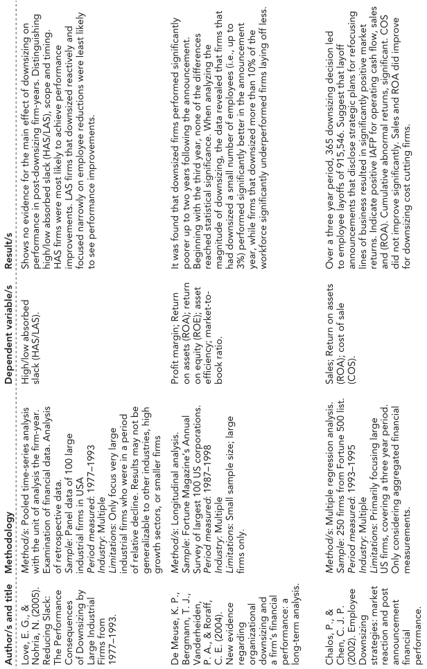

NOTE: complex table shown as an image of the PDF; the text below is a rough machine extraction and may be mis-aligned.

**extracted text (unreliable layout)**

Page 11

Causes and consequences of downsizing

Volume 17, Issue 4, July 2011 JOURNAL OF MANAGEMENT & ORGANIZATION 507

(*continued*)

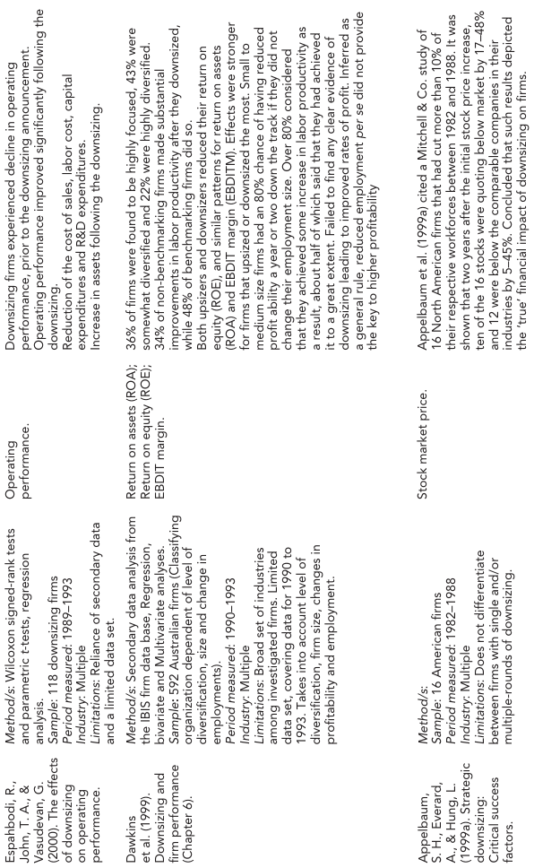

NOTE: complex table shown as an image of the PDF; the text below is a rough machine extraction and may be mis-aligned.

**extracted text (unreliable layout)**

Page 12

Franco Gandolfi and Magnus Hansson

JOURNAL OF MANAGEMENT & ORGANIZATION Volume 17, Issue 4, July 2011 508

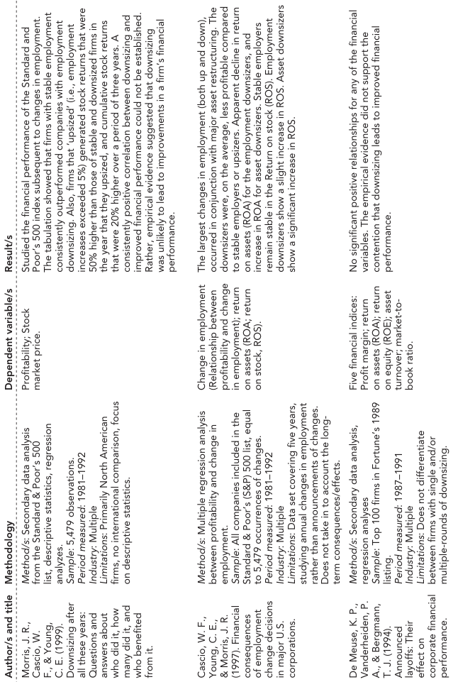

NOTE: complex table shown as an image of the PDF; the text below is a rough machine extraction and may be mis-aligned.

**extracted text (unreliable layout)**

TABLE 1: (CONTINUED) TABLE 1: (CONTINUED)

Page 13

Causes and consequences of downsizing

Volume 17, Issue 4, July 2011 JOURNAL OF MANAGEMENT & ORGANIZATION 509

Worrell, D. L.,

Davidson, W. N.,

& Sharma, V. M.

(1991). Layoff

announcements

and stockholder

wealth.

*Method/s*: Secondary data analysis

based on the DIALOG System of

National Newspaper Index.

*Sample*: 194 fi rms

*Period measured*: 1979–1987

*Industry*: Multiple

*Limitations*: Study did not test the

reaction of the stock market to actual

layoffs, but to their announcement in the

fi nancial press.

Return on stock (ROS). Stock returns of companies for the period from 90 days

prior to the announcement of the downsizing to 90 days

after the announcement. There was a signifi cantly negative

market reaction to the announcements with the cumulative

loss in stock value being about 2% of the value of the

equity of the fi rms. For fi rms that provided restructuring

and consolidation as the reason for the layoffs, there was a

3.6% increase in stock value over the 180-day test period, while among fi rms citing fi nancial distress as the reason for

downsizing, stock values declined an average of 5.6% over

the same period.

Source: Developed for this paper.

also been reported that, in the long run, fi rms embracing asset and employee downsizing have a less positive stock market price development than fi rms adopting upsizing activities (Hillier et al., 2007; Morris et al., 1999). Admittedly, some companies have reaped fi nancial benefi ts following downsizing. In fact, there can be a healthy side to the restructuring and downsizing of organizations. For instance, some fi rms become bloated and, thus, require ‘rightsizing’ in order to bring workforce levels into alignment with the entire organizational system (Hitt, Keats, Harback, & Nixon, 1994). This can be achieved by eliminating unnecessary and/ or redundant work. For instance, in a Canadian study of 1,034 downsized fi rms, Axmith (1995) found that the majority of surveyed companies reported improved levels of earnings, employee productivity, and customer service, as well as decreased overall costs. However, the vast majority of evidence suggests that downsizing activities fall short of meeting fi nancial and organizational objectives (Cameron, Whetten, & Kim, 1987; Cascio, 1998; Gandolfi & Neck, 2008). Nonetheless and perhaps surprisingly, despite its dismal track record to date, downsizing has remained a most popular strategy of choice (Farrell & Mavondo, 2004; Gandolfi & Hansson, 2010; Littler & Gandolfi , 2008). Downsizing generates a range of *organizational* consequences. Downsizing consolidates decision-making at higher levels of organizational hierarchy, and often produces a crisis mentality focused on immediate needs at the expense of long-term planning (Cameron, 1994). Further, downsizing generates a loss of innovation with less tolerance for risk and failure associated with creative activity (Richtnér & Ahlström, 2006). Ironically, although overall communication becomes restricted, the organizational climate becomes more politicized as special interest groups organize and become more vocal (Burke & Cooper, 2000; Littler & Hansson, 2007). Other negative consequences following downsizing activities include

Page 14

Franco Gandolfi and Magnus Hansson

JOURNAL OF MANAGEMENT & ORGANIZATION Volume 17, Issue 4, July 2011 510

victims’ careers (Cameron et al., 1991; Dolan et al., 2000). Victims have also reported a loss of earning power upon reemployment (Konovsky & Brockner, 1993). Studies further suggest that victims have encountered feelings of cynicism, uncertainty, and decreased levels of commitment and loyalty that carry over to the next job (Macky, 2004).

Survivors Scholars have studied extensively the emotions, behaviors, and attitudes displayed by survivors during and after downsizing activities. These symptoms have come to be known as survivor ‘sicknesses’ (Appelbaum & Donia, 2001). One dominant stream of the downsizing research has focused on the *survivor syndrome* as a cluster of negative workforce outcomes (Appelbaum et al., 1997; Brockner, 1988; Brockner, Grover, Reed, & DeWitt, 1992; Brockner, Grover, Reed, DeWitt, & O’Malley, 1987). These psychological outcomes generate, for example, ‘new’ psychological contracts (Barker & Duhaime, 1997; Barker & Mone, 1994; Guest, 1998; Robbins & Pearce, 1992; Rousseau & McLean-Parks, 1993; Sparrow, 1998), reduced career consciousness (Freeman, 1994; Freeman & Cameron, 1993), decreased organizational involvement (Brockner et al., 1988a,b), decreased levels of work quality (Makawatsakul & Kleiner, 2003), and reduced organizational commitment (Brockner et al., 1987; Freeman, 1994; Freeman & Cameron, 1993; Littler, 1998; Littler et al., 2003; Rousseau & McLean-Parks, 1993). Other negative outcomes of downsizing include guilt (Allen, 1997; Devine, Reay, Stainton, & Collins-Nakai, 2003), positive inequity (Brockner et al., 1986a, 1988a, 1988b), anger and arousal (Cutcher-Gershenfeld, 1991), stress (Sverke & Hellgren, 2001), anxiety (Staw, Sandelands, & Dutton, 1981; Shaw & Barrett- Power, 1997), relief (Allen, 1997; Schweiger, Ivancevich, & Power, 1987), and increased job insecurity (Brockner et al., 1985, 1986b, 1987, 1988a, 1988b; Hansson, 2008a).

decreased morale (Wagar, 1998), decreased productivity (Budros, 1997; Yoo & Mody, 2000), and an increased number of confl icts, slower confl ict resolution, and a loss of trust (Cameron, 1994; Cutcher-Gershenfeld, 1991; Hansson, 2008a,b; Littler & Hansson, 2007). Increased levels of individualism and disconnectedness have shown to hinder teamwork, while poor or lack of leadership and an increased level of resistance to change generate conservatism and a threat-rigidity response, leading to a protectionistic stance (Cameron, 1994; Hansson, 2008a; Shaw & Barrett-Power, 1997).

On the other hand, some studies have unveiled positive organizational outcomes, including lower overhead costs, less bureaucracy, faster decisionmaking, smoother communication, greater entrepreneurship, and increased levels of employee productivity (Burke & Cooper, 2000).

Downsizing generates a range of *human* consequences. It has been reported that the human costs of downsizing are immense and far-reaching (Brockner, 1988, 1992; Brockner et al., 1988a, 1988b; Burke & Greenglass, 2000). From the extant literature, it is possible to distinguish between three categories of people directly impacted by downsizing; victims, survivors, and executioners (Allen, 1997; Downs, 1995; Kettley, 1995; Littler, 1998). The following sections present a non-exhaustive account of some representative studies on the identifi ed human consequences of downsizing activities:

Victims Research depicts strong evidence of adverse psychological effects resulting from job loss, including psychological stress, ill health, family problems, marital problems, reduced self-esteem, depression, psychiatric morbidity, helplessness, anxiety, and feelings of social isolation (Dolan et al., 2000; Gandolfi , 2007; Greenglass & Burke, 2001; Havlovic, Bouthillette, & Van der Wal, 1998). There is some evidence suggesting that job loss caused by downsizing has the propensity to generate permanent damage to the

Page 15

Causes and consequences of downsizing

Volume 17, Issue 4, July 2011 JOURNAL OF MANAGEMENT & ORGANIZATION 511

anger (Allen, 1997; Cameron et al., 1991; Noer, 1993). Survivor guilt tends to arise when survivors perceive that their own performance merited no better treatment than that accorded downsized victims (Littler et al., 1997). Scholars have learned it is not the terminations *per se* that create hostility, anger, bitterness, and survivor guilt but the manner in which the terminations are handled (Schweiger et al., 1987). Moreover, bitterness, anger, and disgust regarding the layoffs of co-workers may potentially result in survivor guilt (Appelbaum et al., 1999a, 1999b).

In addition, survivor envy refl ects a survivor’s feelings of envy towards the victims (Campbell- Janison et al., 2001; Kinnie et al., 1998; Littler, 1998). Research suggests that the focus in most downsized fi rms is on the downsizing victims, who are deemed most in need of counseling, support, help, and re-training (Amundson et al., 2004). Victims frequently receive generous benefi ts (Gandolfi , 2006a), including personal assistance like outplacement support, personal and family counseling, and retraining, plus fi nancial compensation, such as severance pay, relocation assistance, and various benefi ts packages (Allen, 1997). Survivors presume victims will obtain either generous retirement incentives or new jobs with more attractive compensation. It is not surprising that Littler (1998, p. 14) found that, at times, ‘survivors start to feel that they are the unlucky ones, the poor idiots left behind to clean up the corporate mess with reduced resources’.

Executioner A downsizing executioner or executor is an employee, manager, or consultant entrusted with the planning, execution, and evaluation of a downsizing activity (Downs, 1995). To date, little research has explored the emotional responses and reactions of the subjects implementing downsizing (Gandolfi & Neck, 2008). Nonetheless, there is some empirical evidence suggesting that the implementers of downsizing suffer from similar psychological and emotional effects as the victims and survivors (Gandolfi , 2007) in that bearing

Survivors tend to display dysfunctional work behaviors and attitudes, such as decreased motivation (Kinnie, Hutchinson, & Purcell, 1998), decreasing morale (Cameron, 1994; Smeltzer & Zener, 1994), increased propensity to leave (Appelbaum et al., 1997; Littler et al., 2003), lowered commitment (Beylerian & Kleiner, 2003), decreased satisfaction (Redman & Keithley, 1998), increased resistance to change (Macky, 2004), increased level of confl icts, and lowered speed of confl ict resolution (Cutcher- Gershenfeld, 1991; Hansson, 2008b).

Further survivor sickness pathologies include increased levels of absenteeism (Campbell- Janison, Worrall, & Cooper, 2001; Gandolfi , 2005), increased employee turnover (Brockner, 1988), decreased employee involvement (Beylerian & Kleiner, 2003), reduced risk taking (Allen, 1997), decreased levels of innovation (Cascio, 1993; Gandolfi & Oster, 2009), decreased employee commitment (Mirvis & Marks, 1992), decreasing morale (Lecky, 1998), and distrust towards management (Cascio, 1993; Greenhalgh & Rosenblatt, 1984). Along the same lines, researchers have documented lowered productivity (Estok, 1996; Kinnie et al., 1998), decreased work performance (Beylerian & Kleiner, 2003), reduced effi ciency (Lee, 1992), reduced job performance (Cameron et al., 1993; Littler, Bramble, & MacDonald, 1994; Littler & Innes, 2003), decreased levels of product and service quality (Fisher & White, 2000), decreased level of learning (Sahdev, 2003), and deteriorated levels of competence in the organization (Gettler, 1998). Gettler (1998) observed similar symptoms among survivors in New Zealand, Australia, and South Africa suggesting the fi ndings were in line with data from the U.S. and Europe (Amundson et al., 2004; Beylerian & Kleiner, 2003; Makawatsakul & Kleiner, 2003). Compounding the survivor syndrome is the survivor guilt represented by the victim’s sense of responsibility or remorse for some offence, and is often expressed in terms of depression, fear, and

Page 16

Franco Gandolfi and Magnus Hansson

JOURNAL OF MANAGEMENT & ORGANIZATION Volume 17, Issue 4, July 2011 512

chosen as a reactive measure to economic crises. Since the mid-1980s, however, downsizing or rightsizing has manifested itself as a proactive human resource strategy (Chadwick et al., 2004; Hitt et al., 1994) and a strategy of choice (Burke & Greenglass, 2000). Thus, downsizing has become decoupled from the business cycle (Littler & Gandolfi , 2008), and the decision to embrace downsizing is no longer determined by fi nancial success and failure (Mellahi & Wilkinson, 2004). This fundamental change connotes that downsizing has attained the status of a restructuring strategy (Cameron, 1994) with the intent of achieving a new organizational structure and a new level of competitiveness (Littler et al., 1997). Consequently, the 1990s saw the elevation of the downsizing strategy as a way of life (Filipowski, 1993) and a corporate panacea (Nelson, 1997). Paradoxically, this development took place despite the absence of downsizing successes.

The active adoption of downsizing has enjoyed continued popularity in the fi rst few years of this new millennium despite the many lackluster results reported in the 1980s and the 1990s. From a change management perspective, the 1990s did not end in 1999, but culminated in the technology-induced fi nancial markets downturn in 2001 (Littler & Gandolfi , 2008), as well as frequently reported multiple layoffs following the current global fi nancial crisis (Sowjanya & Vasanthi, 2009). There is strong empirical evidence demonstrating that downsizing practices have remained fashionable in this new decade (Gandolfi & Neck, 2008; Macky, 2004; Mirabal & DeYoung, 2005). As in the previous two decades, downsizingrelated synonyms and euphemistic terms have appeared in abundance in both the business press and academic literature (Story & Dash, 2008; Weiss, 2008).

Large fi rms, in particular, have continued to downsize and embark upon extensive non- selective (i.e., across-the-board) job cutting since 2001 (Littler & Gandolfi , 2008). This is evident in the downsizing announcements and plant closures in the U.S. and elsewhere over the past three

downsizing responsibilities is emotionally taxing and professionally challenging (Clair & Dufresne, 2004). In sum, a multitude of fi nancial, organizational, and human consequences of downsizing has appeared in the literature. To put a single downsizing consequence forward is problematic and underrates the complexity of the phenomenon. Some frequently reported consequences of downsizing include decreased levels of organizational effi ciency, effectiveness, productivity, and profi tability. Furthermore, downsizing has also shown to produce decreased morale and job satisfaction, increased number of confl icts, slower confl ict resolution, and a loss of trust as well as increased levels of individualism and perceptions of disconnectedness generating a range of psychological outcomes for downsizing victims, survivors, and executioners.

CONTEMPORARY DOWNSIZING PRACTICES As described in the previous section, it is possible to state that downsizing has largely failed to produce the widely anticipated fi nancial and organizational gains, while profound human consequences have emerged among all constituencies within the downsized fi rm. There is some acknowledgment within the business community that downsizing has been destructive (Zyglidopoulos, 2003), yet there is considerable empirical and anecdotal evidence suggesting that the execution of downsizing has continued well into the new millennium (Gandolfi , 2009; Hansson, 2008a,b; Macky, 2004; Mirabal & DeYoung, 2005). In addition, there are widespread expectations that fi rms will continue to resort to downsizing activities (Gandolfi & Hansson, 2010; Littler & Gandolfi , 2008).

Prior to the mid-1980s, downsizing was adopted in situations where employee reductions were undertaken in response to external events and short-term needs (Kozlowski, Chao, Smith, & Hedlung, 1993). This strategy, which was considered reactive downsizing, is intrinsically correlated with the business cycle and purposefully

Page 17

Causes and consequences of downsizing

Volume 17, Issue 4, July 2011 JOURNAL OF MANAGEMENT & ORGANIZATION 513

CONCLUDING REMARKS This research paper has shown that downsizing remains a complex, multifaceted business phenomenon (Datta et al., 2010). While the downsizing literature is extensive and many valuable insights have been gained over the past three decades, the reactive and strategic adoption and practice of downsizing has continued unabated despite its dubious track record (Gandolfi & Hansson, 2010).

Page 18

Franco Gandolfi and Magnus Hansson

JOURNAL OF MANAGEMENT & ORGANIZATION Volume 17, Issue 4, July 2011 514

Finally, this paper has reviewed contributions from the downsizing literature. It has been the authors’ intention to make a widely scattered, multifaceted, and notably diverse fi eld of research much more readily available to scholars and business professionals. As previously noted, the vast majority of the downsizing literature is paradigmatically situated within the social action theory within the functionalistic approach consisting of a whole range of ontological, epistemological, and methodological assumptions (Burrell & Morgan, 1979). Still, within the social action theory realm, explanations of the social world must be adequate at the level of meaning. Explanations of social affairs must account for the way in which individuals attach subjective meaning to situations and orient their action in accordance with their perceptions of those situations. This has not been clear within the previous research. Thus, the authors argue that future research should take into account such aspects in order to combine theoretical richness and methodological rigor.

References Aldrich, H. E., & Auster, E. R. (1986). Even dwarfs

start small: Liabilities of age and size and their strategic implications. In B. M. Staw & L. L. Cummings (Eds.), *Research in organization behavior* (pp. 165–198). Greenwich, CT: JAI Press.

contrast the impact of organizational dynamics, management actions, and various types of change during growth and decline stages, stable and unstable environment, and periods of technological stability and change.

As established in this current paper, downsizing activities generate a wide range of fi nancial, organizational, and human consequences. The literature on downsizing consequences has shown to be diverse and a number of contradictory fi ndings to the mainstream research have been presented. On an aggregated level, and as previously noted, the overall consequences of downsizing activities have presented themselves to be largely negative, particularly at the organizational and human levels. Nonetheless, some positive downsizing outcomes have been reported, primarily at the fi nancial level.

Page 19

Causes and consequences of downsizing

Volume 17, Issue 4, July 2011 JOURNAL OF MANAGEMENT & ORGANIZATION 515

empirical evidence. *Strategic Management Journal, 18*, 13–27. Barker, V. L., & Mone, M. A. (1994).

Retrenchment: Cause of turnaround or consequence of decline. *Strategic Management Journal, 15*, 395–405. Beaumont, P. B., & Harris, R. I. D. (2003). Internal

wage structures and organizational performance. *British Journal of Industrial Relations, 41*, 53–70. Beylerian, M., & Kleiner, B. H. (2003). The down-

sized workplace. *Management Research News, 26*, 2–4. Brockner, J. (1988). The effects of layoffs on survi-

vors: Research theory and practice. *Research in Organizational Behavior, 10*, 213–255. Brockner, J. (1992). Managing the effects of

lay-offs on survivors. *California Management Review, 34*(2), 9–28. Brockner, J., Davy, J., & Carter, C. (1985). Layoffs,

self-esteem and survivor guilt: Motivational, affective, and attitudinal consequences. *Organizational Behavior and Human Decision Processes, 16*, 229–244. Brockner, J., Greenberg, J., Brockner, A., Bortz, J,

Davy, J., & Carter, C. (1986a). Layoffs, equity theory, and work performance: Further evidence of the impact of survivor guilt. *Academy of Management Journal, 26*(2), 373–384. Brockner, J., Greenberg, J., Brockner, A., Bortz, J.,

Davy, J., & Carter, C. (1986b). Layoffs, equity theory and work motivation: Further evidence for the impact of survivor guilt. *Academy of Management Journal, 29*, 373–384. Brockner, J., Greenberg, J., & Grover, S. (1988).

The impact of layoffs on survivors: Insights from interpersonal and organizational justice theory. In J. Carrol (Ed.), *Advances in applied social psychology: Business settings* (pp. 4575). Hillsdale, NJ: Erlbaum. Brockner, J., Grover, S., & Blonder, M. (1988).

Predictors of survivors’ job involvement following layoffs: A fi eld study. *Journal of Applied Psychology, 73*(3), 436–442. Brockner, J., Grover, S., Reed, T, F., & DeWitt, R.

E. (1992). Layoffs, job insecurity, and survivors’ work effort: Evidence of an inverted-U relationship. *Academy of Management Journal, 35*(2), 413–425.

Allen, R. K. (1997). Lean and mean: Workforce

2000 in America. *Journal of Workplace Learning, 9*(1), 34–42. Allen, T. D., Freeman, D. M, Russell, J. E. A.,

Reizenstein, R. C., & Rentz, J. O. (2001). Survivor reactions to organizational downsizing: Does time ease the pain? *Journal of Occupational and Organizational Psychology, 74*(2), 145–164. Altman, E. I. (1971). *Corporate bankruptcy in*

*America.* Lexington, MA: Heath. Amundson, N., Borgen, W., Jordan, S., &

Erlebach, A. (2004). Survivors of downsizing: Helpful and hindering experiences. *The Career Development Quarterly, 52*, 256–271. Anthony, W. P., Perrewe, P. L., & Kacmaar, K. M.

(1996). *Strategic human resource management* (2nd ed.). Fort Worth, TX: Dryden. Appelbaum, S. H., Delage, C., Labibb, N., &

Gualt, G. (1997). The survivor syndrome: Aftermath of downsizing. *Career Development International, 2*(6), 137–146. Appelbaum, S. H., & Donia, M. (2001). The real-

istic downsizing preview: A management intervention in the prevention of survivor syndrome (Part I). *Career Development International, 6*(1), 5–19. Appelbaum, S. H., Everard, A., & Hung, L.

(1999a). Strategic downsizing: Critical success factors. *Management Decision, 37*(7), 535–559. Appelbaum, S. H., Lavigne-Schmidt, S., Peytchev,

M., & Shapiro, B. (1999b). Downsizing: Measuring the cost of failure. *The Journal of Management Development, 18*(5), 436–455. Appelbaum, S. H., Simpson, R., & Shapiro,

B. (1987). The tough test of downsizing. *Organizational Dynamics, 16*(2), 68–79. Atwood, J., Coke, E., Cooper, C., & Loria,

K. (1995). *Has downsizing gone too far?* Jacksonville, FL: University of North Florida, MBA Research Project 6065. Axmith, M. (1995). *1995 dismissal practices survey.*

Toronto: Murray Axmith. Aziz, A., Emanuel, D. C., & Lawson, G. H.

(1988). Bankruptcy prediction – an investigation of cash fl ow based models. *Journal of Management Studies, 25*, 419–437. Barker, V. L., & Duhaime, I. M. (1997). Strategic

change in turnaround process: Theory and

Page 20

Franco Gandolfi and Magnus Hansson

JOURNAL OF MANAGEMENT & ORGANIZATION Volume 17, Issue 4, July 2011 516

*decline: Frameworks, research and prescriptions.* Cambridge, MA: Ballinger. Cameron, K. S., Whetten, D. A., & Kim, M. U.

(1987). Organizational dysfunctions of decline. *Academy of Management Journal, 30*, 126–137. Campbell-Janison, F., Worrall, L., & Cooper, C.

(2001). Downsizing in Britain and its effects on survivors and their organizations. *Anxiety, Stress and Coping, 14*(1), 35–58. Cascio, W. F. (1991). *Costing human resources.*

PWS/Kent. Cascio, W. F. (1993). Downsizing: What do we

know? What have we learned? *Academy of Management Executive, 7*(1), 95–104. Cascio, W. F. (1998). *Applied psychology in human*

*resource management* (5th ed.). Upper Saddle River, NJ: Prentice Hall. Cascio, W. F. (2003). Responsible restructur-

ing: Seeing employees as assets, not costs. *Ivey Business Journal Online*, November 2003, 1–5. Cascio, W. F., Young, C., & Morris, J. (1997).

Financial consequences of employment change decisions in major U.S. corporations. *Academy of Management Journal, 40*(5), 1175–1189. Caulkin, S. (1995). The new avengers – years of

corporate lip services to the importance of people is fi nally catching up: Payment is now due in full. *Management Today,* November 1995, 48–52. Chadwick, C., Hunter, L., & Walston, S. (2004).

Effects of downsizing practices on the performance of hospitals. *Strategic Management Journal, 25*(5), 405–420. Chalos, P., & Chen, C. J. P. (2002). Employee

downsizing strategies: Market reaction and post announcement fi nancial performance. *Journal of Business Finance & Accounting, 29*(5), 847–870. Chopra, A. (2006). Survival. Academy of

Management Conference, Atlanta, August 2006. Clair, J. A., & Dufresne, R. L. (2004). Playing the

grim reaper: How employees experience carrying out a downsizing. *Human Relations, 57*(12), 1597–1625. Crainer, S., & Obleng, E. (1995). Re-engineering:

Overview. In F. T. Stuart Crainger (Ed.), *The fi nancial times handbook of management* (pp. 231–241)*.* Marstons Mills, MA: Pitman. Cutcher-Gershenfeld, J. (1991). The impact on

economic performance of a transformation

Brockner, J., Grover, S., Reed, T., DeWitt, R., &

O’Malley, M. (1987). Survivors’ reactions to layoffs: We get by with a little help for our friends. *Administrative Science Quarterly, 32*, 526–541. Budros, A. (1997). The new capitalism and organi-

zational rationality: The adoption of downsizing programs. *Social Forces, 76*(1), 229–250. Budros, A. (1999). A conceptual framework

for analyzing why organizations downsize. *Organization Science, 10*(1), 69–83. Budros, A. (2002). The mean and lean fi rm of

downsizing: Causes of involuntary and voluntary downsizing strategies. *Sociological Forum, 17*(2), 307–342. Budros, A. (2004). Causes of early and later organi-

zational adoption: The case of corporate downsizing. *Sociological Inquiry, 74*(3), 355–380. Burke, R. J., & Cooper, C. L. (2000). The new

organizational reality: Transition and renewal. In R. J. Burke & C. L. Cooper (Eds.), *The organization in crisis* (pp. 3–19). Malden, MA: Blackwell. Burke, R. J., & Greenglass, E. R. (2000).

Organizational restructuring: Identifying effective hospital downsizing processes. In R. J. Burke & C. L. Cooper (Eds.), *The organization in crisis* (pp. 284–303). Malden, MA: Blackwell. Burrell, G., & Morgan, G. (1979). *Social paradigms*

*and organisational analysis – Elements of the sociology of corporate life*. Lancaster, UK: Ashgate. Cameron, K. S. (1994). Strategies for successful

organizational downsizing. *Human Resource Management, 33*(2), 189–211. Cameron, K. S. (1998). Strategic organizational down-

sizing: An extreme case. In C. L. Cooper & D. Rousseau (Eds.), *Trends in organizational behavior* (Vol. 5, pp. 185–229). New York: John Wiley. Cameron, K. S., Freeman, S. J., & Mishra, A. K.

(1991). Best practices in white-collar downsizing: Managing contradictions. *Academy of Management Executive, 5*(3), 57–73. Cameron, K. S., Freeman, S. J., & Mishra, A. K.

(1993). Downsizing and redesigning organizations. In G. Huber and W. Glick (Eds.), *Organizational change and redesign* (pp. 19–63). New York: Oxford University Press. Cameron, K. S., Sutton, R, I., & Whetten, D.

A. (Eds.). (1988). *Readings in organizational*

Page 21

Causes and consequences of downsizing

Volume 17, Issue 4, July 2011 JOURNAL OF MANAGEMENT & ORGANIZATION 517

Elstein, A. (2008). Research: 22,000 jobs cut on

Wall Street, with more to come. *Crain’s New York Business, Workforce Management.* Accessed 2 June 2008, from http://www.workforce.com/ section/00/article/25/56/87.html Espahbodi, R., John, T. A., & Vasudevan, G.

(2000). The effects of downsizing on operating performance. *Review of Quantitative Finance and Accounting, 15*, 107–126. Estok, D. (1996). The high cost of ‘dumbsizing’.

*Macleans’s, 109*(23), 28–29. Farrell, M., & Mavondo, F. (2004). The effect of

downsizing strategy and reorientation strategy on a learning orientation. *Personnel Review, 33*(4), 383–402. Filipowski, D. (1993). Don’t rush downsizing: Plan,

plan, plan, *Personnel Journal, 72*(11), 64–76. Fisher, S. R., & White, M. A. (2000). Downsizing in

a learning organization: Are there hidden costs? *Academy of Management Review, 25*(1), 244–251. Freeman, S., & Cameron, K. S. (1993).

Organizational downsizing: A convergence and reorientation framework. *Organizational Science, 4*(1), 10–29. Freeman, S. J. (1994). Organizational downsizing

as convergence or reorientation: Implications for human resource management. *Human Resource Management, 33*(2), 213–238. Gandolfi , F. (2005). How do organizations imple-

ment downsizing? – An Australian and New Zealand study. *Contemporary Management Research, 1*(1), 57–68. Gandolfi , F. (2006a). Personal development and

growth in a downsized banking organization: Summary of methodology and fi ndings. *Journal of Human Resource Development International, 9*(2), 207–226. Gandolfi , F. (2006b). *Corporate downsizing demysti-*

*fi ed: A scholarly analysis of a business phenomenon.* Hyderabad, India: The ICFAI University Press. Gandolfi , F. (2007). How do large Australian and

Swiss banks implement downsizing? *Journal of Management & Organization, 13*(2), 145–159. Gandolfi , F. (2008). Refl ecting on downsizing –

what have managers learned? *SAM Advanced Management Journal, 73*(2), 46–56. Gandolfi , F. (2009). Where did downsizing go?

A review of 30 years of a strategic business

in workplace relations. *Industrial and Labor Relations Review, 44*(2), 241–260. Datta, D. K., Guthrie, J. P., Basuil, D., & Pandey,

A. (2010). Causes and effects of employee downsizing: A review and synthesis. *Journal of Management, 36*(1), 281–348. Dawkins, P., Littler, C. R., Valenzuela, M. R., &

Jensen, B. (1999). *The contours of restructuring & downsizing in Australia.* Melbourne Institute of Applied Economic and Social Research, Melbourne University. De Meuse, K. P., Bergmann, T. J., Vanderheiden,

P. A., & Roraff, C. E. (2004). New evidence regarding organizational downsizing and a fi rm’s fi nancial performance: A long-term analysis. *Journal of Managerial Issues, 16*, 155–177. De Meuse, K. P., & Marks, M. L. (2003). *Resizing*

*the organization. Managing layoffs, divestitures, and closings.* San Francisco, CA: Jossey-Bass. De Meuse, K. P., Vanderheiden, P. A., &

Bergmann, T. J. (1994). Announced layoffs: Their effect on corporate fi nancial performance. *Human Resource Management, 33*(4), 509–530. Deffree, S. (2007). Motorola layoffs reach 10,000,

*EDN Electronic News*. Accessed 4, April 2007, from http://www.edn.com/article/CA6547845. html Delorese, A. (1998). *Healing the downsized organi-*

*sation.* New York: Three Rivers Press. Demerjian, C. (2005). HP continues stealth lay-

offs. *The Inquirer*. Accessed 09, February 2005, from http://www.theinquirer.net/en/inquirer/ news/2005/02/09/hp-continues-stealth-layoffs Devine, K., Reay, T., Stainton, L., & Collins-

Nakai, R. (2003). The stress of downsizing: Comparing survivors and victims. *Human Resource Management, 42*, 109–124. Dimitras, A. I., Zanakis, S. H., & Zopounidis, C.

(1996). A survey of business failures with an emphasis on prediction methods and industrial applications. *European Journal of Operational Research, 90*, 487–513. Dolan, S., Belout, A., & Balkin, D. B. (2000).

Downsizing without downgrading: Learning how fi rms manage their survivors. *International Journal of Manpower, 21*(1), 34–46. Downs, A. (1995). *Corporate executions.* New York:

Amacom.

Page 22

Franco Gandolfi and Magnus Hansson

JOURNAL OF MANAGEMENT & ORGANIZATION Volume 17, Issue 4, July 2011 518

Hannan, M. T., & Freeman, J. H. (1988). The

ecology of organizational mortality: American labor unions 1863–1985. *American Journal of Sociology, 94*, 25–52. Hannan, M. T., & Freeman, J. H. (1989).

*Organizational ecology*. Cambridge, MA: Harvard University Press. Hansson, M. (2008a). *On closedowns: Towards a*

*pattern of explanations to the closedown effect.* Doctoral dissertation, Örebro Studies in Business Dissertations, No. 1. Örebro University, Sweden. Hansson, M. (2008b). *When the lights go out,*

*conference proceedings*. The Academy of Management Annual Conference, Anaheim. Hansson, M., & Wigblad, R. (2006a).

Recontextualizing the Hawthorne effect. *Scandinavian Journal of Management, 22*, 120–137. Hansson, M., & Wigblad, R. (2006b). Pyrrhic

victories – Anticipating the closedown effect. *International Journal of Human Resource Management, 17*(5), 938–958. Harrigan, K. R. (1982). Exit decisions in mature

industries. *Academy of Management Journal, 25*, 707–732. Harrington, H. J. (1998). Performance improve-

ment: The downside to quality improvement (the surplus people problem). *The TQM Magazine, 10*(3). http://www.emerald-library. com/brev/10610cb1.html Havlovic, S. J., Bouthillette, F., & Van der Wal, R.

(1998). Coping with downsizing and job loss. *Canadian Journal of Administrative Sciences, 15*, 322–332. Hedberg, B. L. T., Nystrom, P. C., & Starbuck, W.

(1978). Camping on the seesaws: Prescriptions of a self-designing organization. *Administrative Science Quarterly, 21*(1), 41–65. Hillier, D., Marshall, A., McColgan, P., &

Wereman, S. (2007). Employee layoffs, shareholder wealth and fi rm performance: Evidence from the UK. *Journal of Business Finance & Accounting, 34*(3–4), 467–494. Hitt, M. A., Keats, B. W., Harback, H. F., &

Nixon, R. D. (1994). Rightsizing – building and

phenomenon. *The Australasian Journal of Business and Social Inquiry, 7*(1), 40–65. Gandolfi , F., & Hansson, M. (2010). Reduction-

in-force (RIF) – New developments and a brief historical analysis of a business strategy. *Journal of Management & Organization, 16*(5), 727–743. Gandolfi , F., & Neck, P. (2003). Organizational

downsizing: A review of the background, its development, and current status. *The Australasian Journal of Business and Social Inquiry, 1*(1), 16-29. Gandolfi , F., & Neck, P. (2008). Consequences,

payoffs, and fallout of downsizing (A literature review of corporate downsizing: Part 3). *Review of International Comparative Management, 9*(1), 55–78. Gandolfi , F., & Oster, G. (2009). Sustaining

innovation during corporate downsizing. *SAM Advanced Management Journal, 74*(2), 42–53. Gettler, L. (1998). Survey: Downsizing doesn’t cut

costs. *Sydney Morning Herald.* Accessed June 16, 1998, p. 27. Ghemawat, P. (1991). *Commitment: The dynamic of*

*strategy*. New York: Free Press. Greenglass, E. R., & Burke, R. J. (2001). Downsizing

and restructuring, implications for stress and anxiety. *Anxiety, Stress, and Coping, 14*, 1–13. Greenhalgh, L., & Rosenblatt, Z. (1984). Job

Insecurity: Toward conceptual clarity. *Academy of Management Review, 9*(3), 438–448. Griggs, H. E., & Hyland, P. (2003). Strategic

downsizing and learning organizations. *Journal of European Industrial Training, 24*(2–4), 177–187. Guest, D. (1998). Beyond HRM: Commitment

and the contract culture. In P. Sparrow & M. Marchington (Eds.), *Human resource management: The new agenda* (pp. 37–51). London: FT/Pitman Publishing. Guthrie, J. P., & Datta, D. K. (2008). Dumb and

dumber. The impact of downsizing on fi rm performance as moderated by industry conditions. *Organizational Science, 19*, 108–123. Halley, A. A. (1995). *Downsizing.* Washington

DC Offi ce: The Meridian International Institute. Hambrick, D. C., & D’Aveni, R. A. (1988).

Large corporate failures as downward spirals. *Administrative Science Quarterly, 33*, 1–33.

Page 23

Causes and consequences of downsizing

Volume 17, Issue 4, July 2011 JOURNAL OF MANAGEMENT & ORGANIZATION 519

maintaining strategic leadership: A long-term competitiveness. *Organizational Dynamics, 23*, 18–32. Jackson, P., Mellahi, K., & Sparks, L. (2005).

Shutting up shop: Understanding the international exit process in retailing. *Service Industries Journal, 25*, 252–273. Kets de Vries, M., & Balazs, K. (1997). The downsiz-

ing of downsizing. *Human Relations, 50*, 11–50. Kettley, P. (1995). *Employee morale during down-*

*sizing*. Report 291. London: Institute of Employment Studies. Kinnie, N., Hutchinson, S., & Purcell, J. (1998).

Downsizing: Is it always lean and mean? *Personnel Review, 27*(4), 296–311. Konovsky, M. A., & Brockner, J. (1993).

Managing victim and survivor layoff reactions: A procedural justice perspective. In R. Cropanzano (Ed.), *Justice in the workplace*: *Approaching fairness in human resource management* (pp. 133–153). Mahwah, NJ: Lawrence Erlbaum. Kozlowski, S. W. J., Chao, G. T., Smith, E., &

Hedlung, J. (1993). Organizational downsizing: Strategies, interventions, and research implications. In C. L. Cooper & I. T. Robertson (Eds.), *International review of industrial and organizational psychology* (pp. 264–332). London: Wiley. Krane, J. (2002). IBM’s unannounced layoffs near

5,000 mark. *CRN*, May 31. Accessed http:// www.crn.com/it-channel/18820762 Lamsa, A. M., & Takala, T. (2000). Downsizing

and ethics of personnel dismissals – The case of Finnish managers. *Journal of Business Ethics, 23*, 389–399. Lecky, S. (1998). The failure of slash & earn.

*Sydney Morning Herald,* 83–87. Lee, C. (1992). After the cuts. *Training*, 17–23. Lee, S., & Alexander, J. (1999). Managing hospitals

in turbulent times: Do organizational changes improve hospital survival? *Health Service Research, 34*(4), 923–946. Littler, C. R. (1998). Downsizing organisations:

The dilemmas of change. *Human Resources Management Bulletin.* Sydney: CCH Australia. Littler, C. R. (2000). Comparing the downsizing

experiences of three countries: A restructuring cycle? In R. J. Burke & C. L. Cooper (Eds.),

*The organization in crisis* (pp. 58–77). Malden, MA: Blackwell. Littler, C. R., Bramble, T., & MacDonald, J. (1994).

*Organizational restructuring: Downsizing, delayering and managing change at work.* Canberra: AGPS. Littler, C. R., Dunford, R., Bramble, T., & Hede,

A. (1997). The dynamics of downsizing in Australia and New Zealand. *Asia Pacifi c Journal of Human Resources, 35*(1), 65–79. Littler, C. R., & Gandolfi , F. (2008). *What hap-*

*pened to downsizing? Organizational continuity, managerial fashion, & signaling*. Academy of Management Conference. Anaheim, CA. Littler, C. R., & Hansson, M. (2007). *Closure and*

*downsizing: Integrating overlapping literatures*. Academy of Management Annual Conference. Philadelphia, PA. Littler, C. R., & Innes, P. (2003). Downsizing and

deknowledging the fi rm. *Work, Employment and Society, 17*(1), 73–100. Littler, C. R., Wiesner, R., & Dunford, R. (2003).

The dynamics of delayering: Changing management structures in three countries. *Journal of Management Studies, 40*(2), 225–256. Love, G. E., & Nohria, N. (2005). Reducing slack:

The performance consequences of downsizing by large industrial fi rms, 1977-93. *Strategic Management Journal, 26,* 1087-1108. Luft, J., & Shields, M. D. (2003). Mapping man-

agement accounting: Graphics and guidelines for theory-consistent empirical research. *Accounting, Organizations and Society, 28*, 169–249. Luthans, B. C., & Sommer, S. M. (1999). The

impact of downsizing on workplace attitudes. *Group and Organization Management, 24*(1), 46–70. Macky, K. (2004). Organisational downsizing

and redundancies: The New Zealand workers’ experience. *New Zealand Journal of Employment Relations, 29*(1), 63–87. Makawatsakul, N., & Kleiner, B. H. (2003). The

effect of downsizing on morale and attrition. *Management Research News, 26*, 2–4. Marks, M. L., & De Meuse, K. P. (2003). The

realities of resizing. In K. P. De Meuse & M. L. Marks (Eds.), *Resizing the organization. Managing layoffs, divestitures, and closings* (pp. 1–39). San Francisco, CA: Jossey-Bass.

Page 24

Franco Gandolfi and Magnus Hansson

JOURNAL OF MANAGEMENT & ORGANIZATION Volume 17, Issue 4, July 2011 520

Martino, M. (2007). Pfi zer: Top 5 layoffs in 2007.

*FierceBiotech*, October 15, 2007. McGregor, J. (2008). The stealth layoff.

*BusinessWeek*, May 16, 2008. McKinley, W., Sanchez, C. M., & Schick, A.

G. (1995). Organizational downsizing: Constraining, cloning, and learning. *Academy of Management Executive, 9*, 32–42. Mellahi, K., & Wilkinson, A. (2004). Organizational

failure: A critique of recent research and a proposed integrative framework. *International Journal of Management Review, 5/6*(1), 21–41. Mirabal, N., & DeYoung, R. (2005). Downsizing

as a strategic intervention. *Journal of American Academy of Business, 6*(1), 39–45. Mirvis, P. H., & Marks, M. L. (1992). *Managing*

*the merger: Making it work.* Englewood Cliffs, NJ: Prentice Hall Direct. Montgomery, C. A., & Thomas, A. R. (1988).

Divestments: Motives and gains. *Strategic Management Journal, 9*(1), 93–97. Morris, J. R., Cascio, W. F., & Young, C. E.

(1999). Downsizing after all these years: Questions and answers about who did it, how many did it, and who benefi ted from it. *Organizational Dynamics, 27*(3), 78–87. Mroczkowski, T., & Hanaoka, M. (1997). Effective

rightsizing strategies in Japan and America: Is there a convergence of employment practices? *The Academy of Management Executive, 11*(2), 57–67. Nelson, B. (1997). The care of the un-downsized.

*Training & Development, 51*(4), 40–43. Noer, D. (1993). *Healing the wounds: Overcoming*

*the trauma of layoffs and revitalizing downsized organizations.* San Francisco, CA: Jossey-Bass. Ogg, E. (2007). Dell to lay off 10 percent of work-

force. *CNET News.com*, May 31. http://news. cnet.com/8301-10784_3-9724562-7.html Radcliffe, V. S., Campbell, D. R., & Fogarty, T. J.

(2001). Exploring downsizing: A case study on the use of accounting information. *Journal of Management Accounting Research, 1*, 131–157. Read, M. (2008). Celent: 200,000 US banking

jobs at risk. *USA Today*. Accessed January 4, 2008 from http://www.usatoday.com/money/ economy/2008-04-01-3967896049_x.htm Redman, T., & Keithley, D. (1998). Downsizing

goes east? Employment re-structuring in

post-socialist Poland. *The International Journal of Human Resource Management, 9*(2), 274–295. Richtnér, A., & Ahlström, P. (2006). Organizational

downsizing and innovation. *SSE/EFI Working Paper Series in Business Administration*, 1. Richtmyer, R. (2002). IBM workers fear the axe.

*CNNMoney*, May 10, 2002. Accessed from http://www.money.cnn.com/2002/05/09/technology/ibm/index.htm Robbins, K. D., & Pearce, II, J. A. (1992).

Turnaround: Retrenchment and recovery. *Strategic Management Journal, 13*, 287–309. Rousseau, D. M., & McLean-Parks, J. (1993). The

contracts of individuals in organizations. In L. L. Cummings & B. M. Staw (Eds.), *Research on organizational behavior* (pp. 1–43). Greenwich, CT: JAI Press. Ryan, L., & Macky K. A. (1998). Downsizing orga-

nizations: Uses, outcomes and strategies. *Asia Pacifi c Journal of Human Resources, 36*(2), 29–45. Sahdev, K. (2003). Survivors’ reactions to downsiz-

ing: The importance of contextual factors. *Human Resource Management Journal, 13*(4), 56–74. Schweiger, D. M., Ivancevich, J. M., & Power, F. R.

(1987). Executive actions for managing human resources before and after acquisition. *Academy of Management Executive, 1*(2), 127–138. Shaw, J. B., & Barrett-Power, E. (1997). A concep-

tual framework for assessing organization, work group and individual effectiveness during and after downsizing. *Human Relations, 50*(2), 109–127. Smeltzer, L. R., & Zener, M. F. (1994). Minimizing

the negative effect of employee layoffs through effective announcements. *Employee Counselling Today, 6*(4), 3–9. Sowjanya, M., & Vasanthi, V. (2009). *Managing down-*

*turn without downsizing (A): US fi nancial crisis and layoffs.* Hyderabad, India: IBS Case Development Centre. http://www.ibscdc.org/Case_Studies/ Strategy/Troubled%20Times/TRT0138.htm Sparrow, P. (1998). New organizational forms,

processes, jobs and psychological contracts: Resolving the HRM issues. In P. Sparrow & M. Marchington (Eds.), *Human resource management: The new agenda* (pp. 117–141). London: Financial Times/Pitman Publishing. Starbuck, W. H., Greve, A., & Hedberg, B. L. T.

(1978). Responding to crisis. *Journal of Business Administration, 9*, 111–137.

Page 25

Causes and consequences of downsizing

Volume 17, Issue 4, July 2011 JOURNAL OF MANAGEMENT & ORGANIZATION 521

Staw, B. M., Sandelands, L. E., & Dutton, J. E.

(1981). Threat-rigidity effects in organizational behavior: A multilevel analysis. *Administrative Science Quarterly, 26*, 501–524. Story, L., & Dash, E. (2008). For Wall Street work-

ers, ax falls quietly. *The New York Times*, May 16, 2008. Sverke, M., & Hellgren, J. (2001). Unionized

employees’ perceptions of role stress and fairness during organizational downsizing: Consequences for job satisfaction, union satisfaction and well-being. *Economic and Industrial Democracy, 22*, 543–567. Thornhill, A., & Saunders, M. N. K. (1998). The

meanings, consequences and implications of the management of downsizing and redundancy: A review. *MCB Personnel Review, 27*(4), 271–295. Thorpe, R., Holt, R., Macpherson, A., & Pittaway,

L. (2005). Using knowledge within small and medium-sized fi rms: A systematic review of the evidence. *International Journal of Management Reviews, 7*(4), 257–281. Wagar, T. (1998). Exploring the consequences

of workforce reduction. *Canadian Journal of Administrative Sciences, 15*, 300–309. Weiss, D. C. (2008). Humor columnist takes aim at

stealth layoffs. *ABA Journal*, May 23, 2008.

Whetten, D. A. (1980). Organizational decline:

A neglected topic in organizational science. *Academy of Management Review, 5*(4), 577–588. Worrell, D. L., Davidson, W. N., & Sharma, V. M.

(1991). “Layoff announcements and stockholder wealth”. *Academy of Management Journal, 34,* 662-678. Yoo, H., & Mody, B (2000). Predictors of down-

sizing in the US local telephone industry. *Information Society, 13*, 23–33. Zammuto, R. F., & Cameron, K. S. (1985).

Environmental decline and organizational response. In B. M. Staw & L. L. Cummings (Eds.), *Research in organizational behavior* (pp. 171–222). Greenwich, CT: JAI Press. Zatzick, C. D., & Iverson, R. D. (2006). High-

involvement management and workforce reduction: Competitive advantage or disadvantage. *The Academy of Management Journal, 49*(5), 999–1015. Zemke, R. (1990). The ups and downs of downsiz-

ing. *Training*, November 1990, 27–34. Zyglidopoulos, S. C. (2003). The impact of down-

sizing on the corporate reputation for social performance. *Journal of Public Affairs, 4*(1), 11–25.

*Received 28 April 2010 Accepted 19 February 2011*

[figure not shown]

NOTE: figure/graphic rendered as an image from the PDF; its content is not machine-readable text. Caption (if any) follows as the next block.

**text found inside the figure**

The Future of Technical and Vocational Education and Training:

Global challenges and possibilities

Hong Kong Institute of Education and UNESCO International Centre for Technical and Vocational

Education and Training, Bonn, Germany)

**management**

**PTY LTD**

Where to now for vocational education and training in Africa? – *Simon McGrath*

Teacher education in TVET: Developing a new paradigm – *Shyamal Majumdar*

TVET and the poor: Challenges and possibilities – *Stephen Lamb*

The implications of skills deepening for vocational education and training in Australia – *Tom Karmel*

Is skill training a good investment for the poor? The evidence from Pakistan – *Shehryar Janjua*

Informal training for skilled workers: Issues arising from a qualitative study in four sites in Rajasthan and Madhya Pradesh – *Claire Noronha and Tanuka Endow*

TVET initiatives in Southeast Asian countries in response to increasing labour mobility within the region and beyond – *Paryono Paryono*

Global skills and mobility challenges and possibilities for VET: A cross-border cross-sectoral case study – *Roslyn Cameron and Terry O’Hanlon-Rose*

Building future sustainability and democratic practices: The role of adult education in post-confl ict communities – *Georgia Lysaght and Peter Kell*

Offshore teaching practice in the Australia-Pacifi c Technical College: A case study in the South Pacifi c – *Anthony Bailey*